# Using Spatially-Stratified Cross-Validation to Create UHC Plots

Althea ArchMiller and John Fieberg

2019-03-04

## Spatially-Stratified Cross validation

In this vignette, we demonstrate how one can use spatially-stratified cross validation to construct UHC plots. We will again simulate data where the species distribution is driven by elevation ($x_1$) and precipitation ($x_2$) with the probability of selecting locations proportional to $\exp(0.5x_{1} - x_{2})$. We will first generate used and available points, then associate random ($x$, $y$) spatial coordinates to these points

```r
library(uhcplots)

# ### Specify Parameters

# Global settings
nused<- 100
navail <- 10000
ntemp <- 1000000
nsims <- 1000 # M from paper

# Example-specific settings
example <- "missing predictor"
set.seed(1000)
betas <- c(0.5, -1)
xlabs <- c("Easting", "Northing")
corx <--0.3
```

Simulate data using the *uhcdatasimulator* function. This time, we will only simulate one dataset and use cross-validation to explore model transferability.

```r
simdat <- uhcdatasimulator(nused = nused,
                             navail = navail,
                             betas = betas,
                             corx = corx,
                             ntemp = ntemp,
                             example = example)
```

Next, we generate x and y coordinates from uniform distributions and associated these coordinates with the used and available points.

```r
# Add in spatial coordinates, correlated with elev and precip
xcoord <- runif(nrow(simdat),0,1)
ycoord <- runif(nrow(simdat),0,1)

xo<-order(simdat$elev*4+simdat$precip)
simdat<-simdat[xo,]
xo<-order(xcoord+rnorm(nrow(simdat), 0, 0.3))
simdat$xcoord<-xcoord[xo]

xo<-order(4*simdat$precip+simdat$elev)
simdat<-simdat[xo,]
xo<-order(ycoord+rnorm(nrow(simdat), 0, 0.3))
simdat$ycoord<-ycoord[xo]
```

OK. Lets look at the correlations among our predictors and also their correlations with the ($x$, $y$) spatial coordinates. This will require the GGally library.

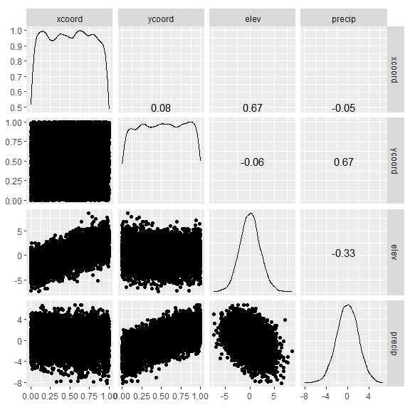

```r
GGally::ggscatmat(simdat, columns = c("xcoord", "ycoord", "elev", "precip"))
```

Lets look at the data spatially.

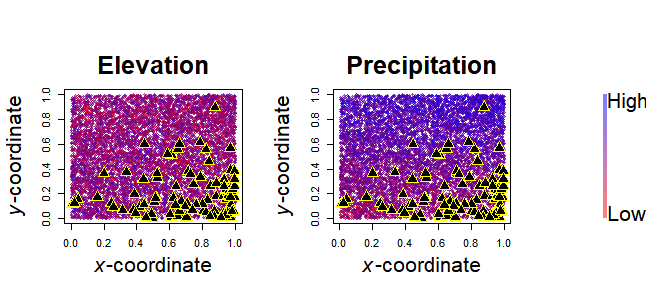

```r
bg<-"black" #background color of used points
rc<-"yellow" #ring color of used points
pch.u<-24 #pch for used points
par(oma=c(0,0,3,0), mar=c(5.1, 5.1, 4.1, 2.1),cex.lab=2, cex.main=2.4)
layout(matrix(c(1,1,2,2,3), nrow=1))
# Create a function to generate a continuous color palette
rbPal <- colorRampPalette(c(rgb(1,0,0,0.5),rgb(0,0,1,0.5)),alpha=T)

#Plot tra
simdat$Col <- rbPal(10)[as.numeric(cut(simdat$elev,breaks = 10))]
with(simdat[simdat$y==0,],
     plot(xcoord, ycoord,
     col=simdat$Col, pch=20, cex=1,main="Elevation",
     ylab=expression(paste(italic(y), "-coordinate")),
     xlab=expression(paste(italic(x), "-coordinate"))))
with(simdat[simdat$y==1,],
     points(xcoord, ycoord,
           pch=pch.u, cex=1.8, col=rc, bg=bg))

simdat$Col <- rbPal(10)[as.numeric(cut(simdat$precip,breaks = 10))]
with(simdat[simdat$y==0,],
     plot(xcoord, ycoord,
          col=simdat$Col, pch=20, cex=1,main="Precipitation",
          ylab=expression(paste(italic(y), "-coordinate")),
          xlab=expression(paste(italic(x), "-coordinate"))))
with(simdat[simdat$y==1,],
     points(xcoord, ycoord,
            pch=pch.u, cex=1.8, col=rc, bg=bg))
rbPal <- colorRampPalette(c('red','blue'))

plot(0:1, 0:1, type="n", bty="n", xaxt="n", yaxt="n", xlab="", ylab="")
SDMTools::legend.gradient(cbind(x=c(0,.1,.10,0),y=c(1,1,0,0)),
                          cols = colorRampPalette(c(rgb(1,0,0,0.5),
                                                    rgb(0,0,1,0.5)),
                                                  alpha=T)(10),
                          title = "", limits=c("",""))
text(0.1, 0.95, "High", cex=2, adj=0)
text(0.1, 0.05, "Low", cex=2, adj=0)
```

### Spatially-stratified cross-validation

To produce a UHC plot using cross-validation, we:

1. Split our data into k folds (separate data sets).
2. Loop from i = 1:k
   1. Fit the data to all data EXCEPT the ith fold
   2. Store $\hat{\beta}$ and $\widehat{\mathrm{cov}}(\hat{\beta})$ to characterize the uncertainty in the parameters (ignoring the intercept if using logistic regression).
   3. Form M predicted distributions for the covariates in the ith fold.
3. Combine all the predictions and then produce UHC plots as in the other examples using data splitting.

Essentially, for each step in the process, we treat the $i^th$ fold as “test data” and the rest of the data as “training data”. Below, we illustrate this process using spatially-stratified folds.

First, we will use the get.block function in the ENMeval package to produce spatially stratifed folds for cross-validation.

```r
# Settings for using uchsimXvalid.R
ncovariates <- 4
model_form_correct <- "y~elev+precip"
model_form_missingP <- "y~elev"
z_colnames <- c("elev","precip","xcoord","ycoord")
xmat_colnames_correct <- c("elev","precip")
xmat_colnames_missingP <- c("elev")

# First, separate "used" from "background" into separate data frames
used_dat <- simdat[simdat$y==1,]
avail_dat <- simdat[simdat$y==0,]

#' Then, use "block" method to separate based on location of used data points
temp_bins <- ENMeval::get.block(occ = used_dat[,c("xcoord","ycoord")],
                          bg.coords = avail_dat[,c("xcoord","ycoord")])

# Finally, associate the bins with the original data
used_dat$kbin <- temp_bins$occ.grp
avail_dat$kbin <- temp_bins$bg.grp
simdat <- rbind(used_dat,avail_dat)
table(simdat$kbin)
```

```
##
##    1    2    3    4
##  940  297 7339 1524
```

Next, we make use of the *uhcsimXvalid* function to create our predicted distribution. Note: this function takes the place of the *uhcsim* function and requires the following arguments:

- data_sim = the data set to be used in cross-validation
- k_folds = the number of bins to split data into
- nsims = the number of simulations (M) used to create the UHC plot.
- nused = the number of used locations in the data set.
- navail = the number of available locations in the data set (ie not used)
- ncovariates = the number of covariates or p in the model
- model_form = the model in the form: “y~x1+x2+…+xp” (including quotations)
- z_colnames = the column names of the environmental characteristics to be plotted with . Takes the form: c(“x1”,“x2”,…,“xp”)
- xmat_colnames = the column names of the environmental characteristics that were used as predictors in the model_form. Takes the form: c(“x1”,“x2”,…,“xp”)

```r
uhcsim_correct <- uhcplots::uhcsimXvalid(data_sim = simdat,
                                  k_folds = 4,
                                  nsims = nsims,
                                  nused = nused,
                                  navail = navail,
                                  ncovariates = 4,
                                  model_form = model_form_correct,
                                  z_colnames = z_colnames,
                                  xmat_colnames = xmat_colnames_correct)

# uhcdenscalc function for all variables
dens_elev_correct <- uhcdenscalc(rand_sims = uhcsim_correct[,,1],
                                dat = subset(simdat,
                                             y==1, select="elev"),
                                avail = subset(simdat,
                                               y==0, select="elev"))
dens_prec_correct <- uhcdenscalc(rand_sims = uhcsim_correct[,,2],
                                dat = subset(simdat,
                                             y==1, select="precip"),
                                avail = subset(simdat,
                                               y==0, select="precip"))
dens_xcoor_correct <- uhcdenscalc(rand_sims = uhcsim_correct[,,3],
                                dat = subset(simdat,
                                             y==1, select="xcoord"),
                                avail = subset(simdat,
                                               y==0, select="xcoord"))
dens_ycoor_correct <- uhcdenscalc(rand_sims = uhcsim_correct[,,4],
                                 dat = subset(simdat,
                                              y==1, select="ycoord"),
                                 avail = subset(simdat,
                                                y==0, select="ycoord"))
```

Now, we produce our UHCplots as before using *uhcdensplot*.

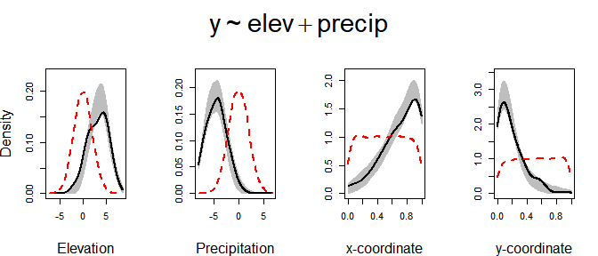

```r
par(mfrow=c(1,4), oma=c(0,0,2,0))
uhcdensplot(densdat = dens_elev_correct$densdat,
            densrand = dens_elev_correct$densrand,
            densavail = dens_elev_correct$densavail,
            includeAvail = T,
            includeLegend = F)
   mtext(outer=F, side=2, line=3, "Density", cex=1)
   mtext(outer=F, side=1, line=4, "Elevation", cex=1.0)
uhcdensplot(densdat = dens_prec_correct$densdat,
            densrand = dens_prec_correct$densrand,
            densavail = dens_prec_correct$densavail,
            includeAvail = T,
            includeLegend = F)
   mtext(outer=F, side=1, line=4, "Precipitation", cex=1.0)
uhcdensplot(densdat = dens_xcoor_correct$densdat,
            densrand = dens_xcoor_correct$densrand,
            densavail = dens_xcoor_correct$densavail,
            includeAvail = T,
            includeLegend = F)
   mtext(outer=F, side=1, line=4, "x-coordinate", cex=1.0)
uhcdensplot(densdat = dens_ycoor_correct$densdat,
            densrand = dens_ycoor_correct$densrand,
            densavail = dens_ycoor_correct$densavail,
            includeAvail = T,
            includeLegend = F)
   mtext(outer=F, side=1, line=4, "y-coordinate", cex=1.0)
   mtext(outer=T, side=3, line=-1.5,  expression(y %~% elev+precip), adj=0.5, cex=1.8)
```

Lets repeat the plots, but now for a model witout precipitation.

```r
uhcsim_noprec <- uhcplots::uhcsimXvalid(data_sim = simdat,
                                        k_folds = 4,
                                        nsims = nsims,
                                        nused = nused,
                                        navail = navail,
                                        ncovariates = 4,
                                        model_form = model_form_missingP,
                                        z_colnames = z_colnames,
                                        xmat_colnames = xmat_colnames_missingP)

# uhcdenscalc function for all variables
dens_elev_noprec <- uhcdenscalc(rand_sims = uhcsim_noprec[,,1],
                                dat = subset(simdat,
                                             y==1, select="elev"),
                                avail = subset(simdat,
                                               y==0, select="elev"))
dens_prec_noprec <- uhcdenscalc(rand_sims = uhcsim_noprec[,,2],
                                dat = subset(simdat,
                                             y==1, select="precip"),
                                avail = subset(simdat,
                                               y==0, select="precip"))
dens_xcoor_noprec <- uhcdenscalc(rand_sims = uhcsim_noprec[,,3],
                                 dat = subset(simdat,
                                              y==1, select="xcoord"),
                                 avail = subset(simdat,
                                                y==0, select="xcoord"))
dens_ycoor_noprec <- uhcdenscalc(rand_sims = uhcsim_noprec[,,4],
                                 dat = subset(simdat,
                                              y==1, select="ycoord"),
                                 avail = subset(simdat,
                                                y==0, select="ycoord"))
```

And, finally, our UHC plot! Clearly, the model without precipitation fails to predict the distribution of precipitation values or the distribution of locations in space.

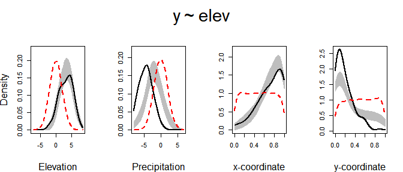

```r
par(mfrow=c(1,4), oma=c(0,0,2,0))
uhcdensplot(densdat = dens_elev_noprec$densdat,
            densrand = dens_elev_noprec$densrand,
            densavail = dens_elev_noprec$densavail,
            includeAvail = T,
            includeLegend = F)
   mtext(outer=F, side=2, line=3, "Density", cex=1)
   mtext(outer=F, side=1, line=4, "Elevation", cex=1.0)
uhcdensplot(densdat = dens_prec_noprec$densdat,
            densrand = dens_prec_noprec$densrand,
            densavail = dens_prec_noprec$densavail,
            includeAvail = T,
            includeLegend = F)
   mtext(outer=F, side=1, line=4, "Precipitation", cex=1.0)
uhcdensplot(densdat = dens_xcoor_noprec$densdat,
            densrand = dens_xcoor_noprec$densrand,
            densavail = dens_xcoor_noprec$densavail,
            includeAvail = T,
            includeLegend = F)
   mtext(outer=F, side=1, line=4, "x-coordinate", cex=1.0)
uhcdensplot(densdat = dens_ycoor_noprec$densdat,
            densrand = dens_ycoor_noprec$densrand,
            densavail = dens_ycoor_noprec$densavail,
            includeAvail = T,
            includeLegend = F)
   mtext(outer=F, side=1, line=4, "y-coordinate", cex=1.0)
   mtext(outer=T, side=3, line=-1.5,  expression(y %~% elev), adj=0.5, cex=1.8)
```